# Andromeda Light | [Demo](https://demo.gethugothemes.com/andromeda-light) | [Page Speed (92%)](https://lighthouse-dot-webdotdevsite.appspot.com//lh/html?url=https%3A%2F%2Fdemo.gethugothemes.com%2Fandromeda-light%2F)

[figure not shown]

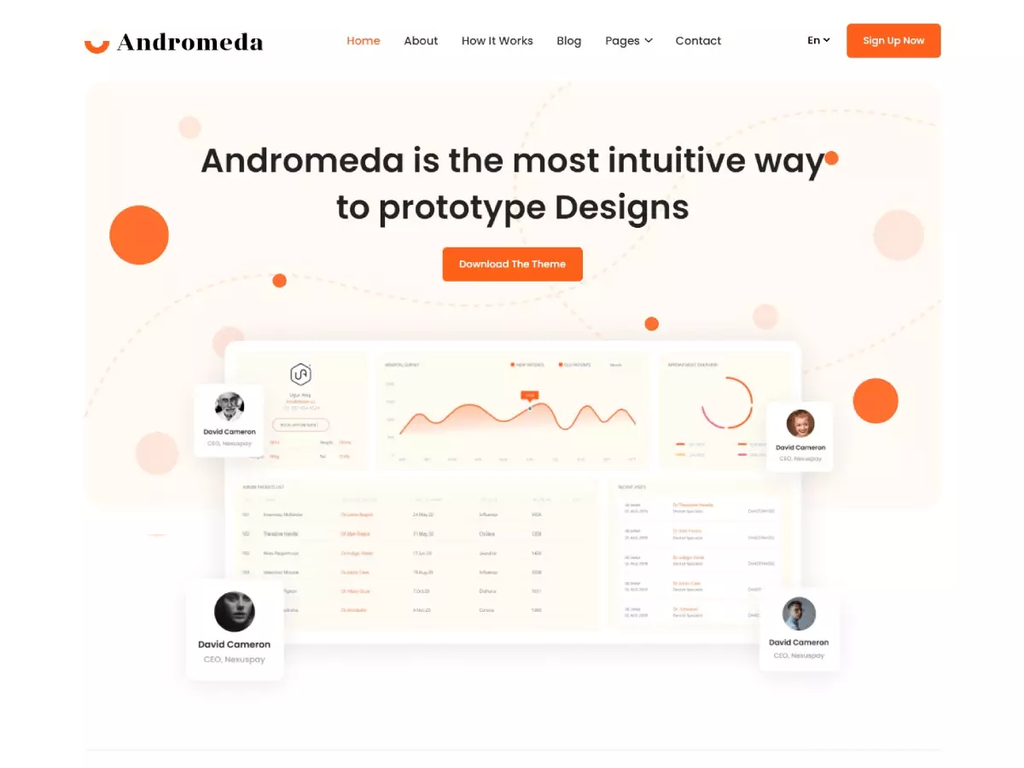

## Discover Free & Premium Features

[output not shown]

## Local development

```bash
# clone the repository
git clone git@github.com:gethugothemes/andromeda-light.git

# cd in the project directory
$ cd andromeda-light/exampleSite/

# Start local dev server
$ hugo server --themesDir ../..
```

Or Check out [Full Documentation](https://docs.gethugothemes.com/andromeda/?ref=github).

## Content Management System

[figure not shown]

This project has been pre-configured to work with [Forestry](https://forestry.io) a git-based CMS, [import your repository in Forestry](https://app.forestry.io/quick-start?repo=gethugothemes/andromeda-light&engine=hugo&version=0.87.0) and you will be able to edit and preview your site ✨.

Any changes you make in Forestry will be committed back to the repo and deployed if you use Netlify.

## Deployment and hosting

[figure not shown]

## Prefer a video? (Hugo + Netlify + Forestry)

Build your website with **Andromeda Light Hugo** theme by following these easy steps (No Coding Required!) [Video Tutorial](https://youtu.be/ResipmZmpDU).

## Reporting Issues

We use GitHub Issues as the official bug tracker for the andromeda light Template. Please Search [existing issues](https://github.com/gethugothemes/andromeda-light/issues). Someone may have already reported the same problem. If your problem or idea has not been addressed yet, feel free to [open a new issue](https://github.com/gethugothemes/andromeda-light/issues).

## License

Copyright © Designed by [Themefisher](https://themefisher.com) & Developed by [Gethugothemes](https://gethugothemes.com)

**Code License:** Released under the [MIT](https://github.com/gethugothemes/andromeda-light/blob/master/LICENSE) license.

**Image license:** The images are only for demonstration purposes. They have their licenses. We don’t have permission to share those images.

## Special Thanks

- [Bootstrap](https://getbootstrap.com)
- [Jquery](https://jquery.com)
- [Aos](https://michalsnik.github.io/aos)
- [Line awesome](https://icons8.com/line-awesome)
- [Rellax](https://dixonandmoe.com)
- [Swiper](https://swiperjs.com)
- [Google Fonts](https://fonts.google.com)
- [All Contributors](https://github.com/gethugothemes/andromeda-light/graphs/contributors)

## Hire Us

We are available for **Hiring** for your next HUGO project. Please, check our [services](https://gethugothemes.com/services/?ref=github)

## Premium Themes By Us

[figure not shown]

[figure not shown]

[figure not shown]

**Premium Theme Bundle (40+)**

**Delta**

**Agico**